# Prediction Assignment Writeup - Practical Machine Learning Coursera Course

RLC Velhorst

10-4-2020

# Peer-graded Assignment: Prediction Assignment Writeup

This document is the final report of the Peer Assessment project from Coursera’s course Practical Machine Learning, as part of the Specialization in Data Science by John Hopkins University. It was built in RStudio, using its knitr functions. This analysis meant to be the basis for the course quiz and a prediction assignment writeup.

## Project Goal

The goal of your project is to predict the manner in which 6 participants did a Unilateral Dumbbell Biceps Curl, a weight lifting exercise, based on measurements of on-body sensors. Based on a training dataset, a machine learning model is built. This report describes how the model is built, how cross-validation is used, what the expected out of sample error is and which choices are made during this process. Finally, the prediction model is used to predict 20 test cases.

## Data

### Background

Using devices such as Jawbone Up, Nike FuelBand, and Fitbit it is now possible to collect a large amount of data about personal activity relatively inexpensively. These type of devices are part of the quantified self movement – a group of enthusiasts who take measurements about themselves regularly to improve their health, to find patterns in their behavior, or because they are tech geeks. One thing that people regularly do is quantify how much of a particular activity they do, but they rarely quantify how well they do it. In this project, your goal will be to use data from accelerometers on the belt, forearm, arm, and dumbell of 6 participants. They were asked to perform barbell lifts correctly and incorrectly in 5 different ways. More information is available from the website here: http://web.archive.org/web/20161224072740/http:/groupware.les.inf.puc-rio.br/har (see the section on the Weight Lifting Exercise Dataset).

### Source

The *training* data for this project are available here:

https://d396qusza40orc.cloudfront.net/predmachlearn/pml-training.csv

The *test* data are available here:

https://d396qusza40orc.cloudfront.net/predmachlearn/pml-testing.csv

The data for this project come from this source: http://groupware.les.inf.puc-rio.br/har.

### Prepare data for modeling

```r
## Clean the data

# Select columns which are in both training and test data
commonCols <- intersect(names(testingRaw),names(trainingRaw))
# drop columns containing only NA
noNACols1 <- names(testingRaw)[colMeans(is.na(testingRaw))==0]
noNACols2 <- names(trainingRaw)[colMeans(is.na(trainingRaw))==0]
useColsAll <- intersect(commonCols, intersect(noNACols1, noNACols2))
# drop first  columns which are experiment identifiers, not actual measurements
useCols <- useColsAll[8:length(useColsAll)]

#Use the desired columns to clean both data sets
training <- select(trainingRaw, c(useCols,"classe"))
testing <- select(testingRaw,c(useCols,"problem_id"))

## Split training data
# create a partition of the training dataset used for building the model, using a 70%-30% ratio
set.seed(12345) # for reproducability
inTrain <- createDataPartition(training$classe, p=0.7, list=FALSE)
trainSet <- training[inTrain, ]
# Use the other part of the partition to compute performance and accuracy
testSet <- training[-inTrain, ]
```

There are now three datasets:  
The **trainSet**, which is used to build to model. This data is based on the original *training* data.  
The **testSet**, which is used to evaluate the out-of-sample model performance. This data is based on the original *training* data.  
The **testing** data, which is submitted to the predictive model as final result of the exercise. This data is based on the original *test* data.

### Exploratory data analysis

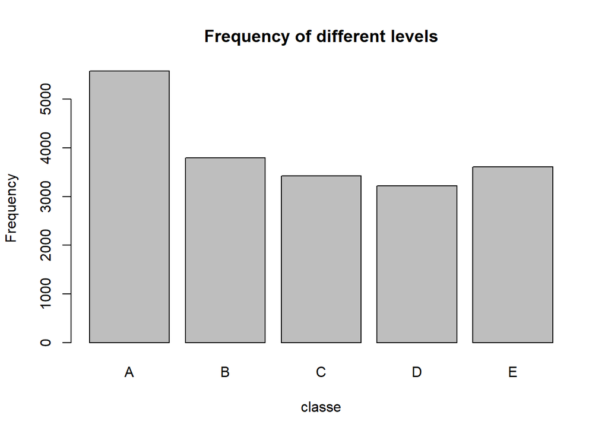

```r
# Show distribution of the target variable
target <- training$classe
plot(target, main="Frequency of different levels", xlab="classe", ylab="Frequency")
```

## Predictive Model

Three different methods are used to built and evaluated a predeictive model. The used methods are: Linear Discriminant Analysis (LDA), a Random Forest model (RF) and a Generalized Boosted Model (GBM).

### Training the model

The three models are built using the default options option of the *caret* package. The variable **classe** is predicted using all variable which resulted from the data cleaning. The *trainSet* dataset is used to train the models.

#### Model 1: Linear Discriminant Analysis

```r
set.seed(12321)
# Fit model
model.lda <- train(classe ~., data=trainSet, method="lda")
```

#### Model 2: Random Forest model

```r
set.seed(12321)
# Fit model
model.rf <- train(classe ~., data=trainSet, method="rf")
```

#### Model 3: Generalized Boosted Model

```r
set.seed(12321)
# Fit model
model.gbm <- train(classe ~., data=trainSet, method="gbm", verbose=FALSE)
```

### Cross-validation of the models

The models are cross-validated useing the validation set approach. The three models are used to predict the *classe* variable in the *testSet* dataset, and the prediction is compared to the original data to estimate the out-of-sample error. A confusionmatrix is computed to investigated the result.

#### Model 1: Linear Discriminant Analysis

```r
# Predicting
prediction.lda <- predict(model.lda, testSet)
# Testing
confMat.lda <- confusionMatrix(prediction.lda, testSet$classe)
```

#### Model 2: Random Forest model

```r
# Predicting
prediction.rf <- predict(model.rf, testSet)
# Testing
confMat.rf <- confusionMatrix(prediction.rf, testSet$classe)
```

#### Model 3: Generalized Boosted Model

```r
# Predicting
prediction.gbm <- predict(model.gbm, testSet)
# Testing
confMat.gbm <- confusionMatrix(prediction.gbm, testSet$classe)
```

#### Confusion Matrices

```r
confMat.lda
```

```
## Confusion Matrix and Statistics
##
##           Reference
## Prediction    A    B    C    D    E
##          A 1397  170  111   59   41
##          B   40  738  112   36  195
##          C  110  128  655  121   92
##          D  123   47  127  720  103
##          E    4   56   21   28  651
##
## Overall Statistics
##
##                Accuracy : 0.7071
##                  95% CI : (0.6952, 0.7187)
##     No Information Rate : 0.2845
##     P-Value [Acc > NIR] : < 2.2e-16
##
##                   Kappa : 0.6289
##
##  Mcnemar's Test P-Value : < 2.2e-16
##
## Statistics by Class:
##
##                      Class: A Class: B Class: C Class: D Class: E
## Sensitivity            0.8345   0.6479   0.6384   0.7469   0.6017
## Specificity            0.9095   0.9193   0.9072   0.9187   0.9773
## Pos Pred Value         0.7857   0.6583   0.5922   0.6429   0.8566
## Neg Pred Value         0.9326   0.9158   0.9224   0.9488   0.9159
## Prevalence             0.2845   0.1935   0.1743   0.1638   0.1839
## Detection Rate         0.2374   0.1254   0.1113   0.1223   0.1106
## Detection Prevalence   0.3021   0.1905   0.1879   0.1903   0.1291
## Balanced Accuracy      0.8720   0.7836   0.7728   0.8328   0.7895
```

```r
confMat.rf
```

```
## Confusion Matrix and Statistics
##
##           Reference
## Prediction    A    B    C    D    E
##          A 1673    3    0    0    0
##          B    1 1135    4    0    0
##          C    0    1 1022   20    0
##          D    0    0    0  942    0
##          E    0    0    0    2 1082
##
## Overall Statistics
##
##                Accuracy : 0.9947
##                  95% CI : (0.9925, 0.9964)
##     No Information Rate : 0.2845
##     P-Value [Acc > NIR] : < 2.2e-16
##
##                   Kappa : 0.9933
##
##  Mcnemar's Test P-Value : NA
##
## Statistics by Class:
##
##                      Class: A Class: B Class: C Class: D Class: E
## Sensitivity            0.9994   0.9965   0.9961   0.9772   1.0000
## Specificity            0.9993   0.9989   0.9957   1.0000   0.9996
## Pos Pred Value         0.9982   0.9956   0.9799   1.0000   0.9982
## Neg Pred Value         0.9998   0.9992   0.9992   0.9955   1.0000
## Prevalence             0.2845   0.1935   0.1743   0.1638   0.1839
## Detection Rate         0.2843   0.1929   0.1737   0.1601   0.1839
## Detection Prevalence   0.2848   0.1937   0.1772   0.1601   0.1842
## Balanced Accuracy      0.9993   0.9977   0.9959   0.9886   0.9998
```

```r
confMat.gbm
```

```
## Confusion Matrix and Statistics
##
##           Reference
## Prediction    A    B    C    D    E
##          A 1643   40    0    0    1
##          B   23 1055   37    3   16
##          C    3   36  975   35    8
##          D    5    4   13  918   11
##          E    0    4    1    8 1046
##
## Overall Statistics
##
##                Accuracy : 0.9579
##                  95% CI : (0.9524, 0.9628)
##     No Information Rate : 0.2845
##     P-Value [Acc > NIR] : < 2.2e-16
##
##                   Kappa : 0.9467
##
##  Mcnemar's Test P-Value : 5.784e-05
##
## Statistics by Class:
##
##                      Class: A Class: B Class: C Class: D Class: E
## Sensitivity            0.9815   0.9263   0.9503   0.9523   0.9667
## Specificity            0.9903   0.9834   0.9831   0.9933   0.9973
## Pos Pred Value         0.9757   0.9303   0.9224   0.9653   0.9877
## Neg Pred Value         0.9926   0.9823   0.9894   0.9907   0.9925
## Prevalence             0.2845   0.1935   0.1743   0.1638   0.1839
## Detection Rate         0.2792   0.1793   0.1657   0.1560   0.1777
## Detection Prevalence   0.2862   0.1927   0.1796   0.1616   0.1799
## Balanced Accuracy      0.9859   0.9548   0.9667   0.9728   0.9820
```

### Choice of the final model

The accuray of the models are: LDA 0.7071 , RF 0.9947 and GBM 0.9579. Therefore the **Random Forest model** is chosen to use on the *testing* dataset, as it achieved the highest accuracy.

## Prediction

The Random Roest model is used to predict the *classe* variable of the *testing* dataset

```r
testingResults <- predict(model.rf, testing)
t(data.frame(testingResults, row.names = testing$problem_id))
```

```
##                1   2   3   4   5   6   7   8   9   10  11  12  13  14  15
## testingResults "B" "A" "B" "A" "A" "E" "D" "B" "A" "A" "B" "C" "B" "A" "E"
##                16  17  18  19  20
## testingResults "E" "A" "B" "B" "B"
```